# Delinquent Analysis Case Study

## Problem Statement

### Context

DRS bank is facing challenging times. Their NPAs (Non-Performing Assets) has been on a rise recently and a large part of these are due to the loans given to individual customers(borrowers). Chief Risk Officer of the bank decides to put in a scientifically robust framework for approval of loans to individual customers to minimize the risk of loans converting into NPAs and initiates a project for the data science team at the bank. You, as a senior member of the team, are assigned this project.

### Objective

To identify the criteria to approve loans for an individual customer such that the likelihood of the loan delinquency is minimized and identify the factors that drive the behavior of loan delinquency.

### Dataset

- ID: Customer ID
- isDelinquent : indicates whether the customer is delinquent or not (1 => Yes, 0 => No)
- term: Loan term in months
- gender: Gender of the borrower
- age: Age of the borrower
- purpose: Purpose of Loan
- home_ownership: Status of borrower's home
- FICO: FICO (i.e. the bureau score) of the borrower

### Domain Information

- Transactor – A person who pays his due amount balance full and on time.
- Revolver – A person who pays the minimum due amount but keeps revolving his balance and does not pay the full amount.
- Delinquent - Delinquency means that you are behind on payments, a person who fails to pay even the minimum due amount.
- Defaulter – Once you are delinquent for a certain period your lender will declare you to be in the default stage.
- Risk Analytics – A wide domain in the financial and banking industry, basically analyzing the risk of the customer.

## Loading Libraries

```python
# Suppressing warnings
import warnings
warnings.filterwarnings("ignore")

# Libraries for handling datasets
import numpy as np
import pandas as pd

# Libraries for visualization
import seaborn as sns
import matplotlib.pyplot as plt
%matplotlib inline

# Libraries for hypothesis testing
import scipy.stats as stats

# Libraries for classification
import statsmodels.api as sm
from statsmodels.tools.tools import add_constant
from statsmodels.stats.outliers_influence import variance_inflation_factor
from sklearn.linear_model import LogisticRegression
from sklearn import tree
from sklearn.tree import DecisionTreeClassifier
from sklearn.model_selection import train_test_split, GridSearchCV
from sklearn.metrics import (accuracy_score, recall_score, precision_score, f1_score,
                             roc_curve, roc_auc_score, precision_recall_curve,
                             make_scorer, confusion_matrix)

# Setting the background theme and font scale for figures
sns.set_theme(style = 'darkgrid', font_scale = 1.15)

# To restrict the float value to 2 decimal places
pd.set_option('display.float_format', lambda x: '%.2f' % x)

# Forcing python to show all columns
#pd.set_option('display.max_columns', None)
#pd.set_option('display.max_rows', None)

# Mounting drive
from google.colab import drive
drive.mount('/content/drive/')
```

## Loading Dataset

```python
# Loading dataset
data_orig = pd.read_csv('/content/drive/MyDrive/Python_files/Loan_Delinquent_Dataset.csv')

# Ensuring the original data remains untouched
df = data_orig.copy()
```

## Overview of Dataset

```python
# Cheking the shape of dataset
print('Dataset has {} rows and {} columns.'.format(df.shape[0], df.shape[1]))
```

```
Dataset has 11548 rows and 8 columns.
```

```python
# Peeking the first 5 rows
df.head()
```

|  | ID | isDelinquent | term | gender | purpose | home_ownership | age | FICO |
| --- | --- | --- | --- | --- | --- | --- | --- | --- |
| 0 | 1 | 1 | 36 months | Female | House | Mortgage | >25 | 300-500 |
| 1 | 2 | 0 | 36 months | Female | House | Rent | 20-25 | >500 |
| 2 | 3 | 1 | 36 months | Female | House | Rent | >25 | 300-500 |
| 3 | 4 | 1 | 36 months | Female | Car | Mortgage | >25 | 300-500 |
| 4 | 5 | 1 | 36 months | Female | House | Rent | >25 | 300-500 |

```python
# Peeking the last 5 rows
df.tail()
```

|  | ID | isDelinquent | term | gender | purpose | home_ownership | age | FICO |
| --- | --- | --- | --- | --- | --- | --- | --- | --- |
| 11543 | 11544 | 0 | 60 months | Male | other | Mortgage | >25 | 300-500 |
| 11544 | 11545 | 1 | 36 months | Male | House | Rent | 20-25 | 300-500 |
| 11545 | 11546 | 0 | 36 months | Female | Personal | Mortgage | 20-25 | >500 |
| 11546 | 11547 | 1 | 36 months | Female | House | Rent | 20-25 | 300-500 |
| 11547 | 11548 | 1 | 36 months | Male | Personal | Mortgage | 20-25 | 300-500 |

```python
# General info on the columns
df.info()
```

```
<class 'pandas.core.frame.DataFrame'>
RangeIndex: 11548 entries, 0 to 11547
Data columns (total 8 columns):
 #   Column          Non-Null Count  Dtype
---  ------          --------------  -----
 0   ID              11548 non-null  int64
 1   isDelinquent    11548 non-null  int64
 2   term            11548 non-null  object
 3   gender          11548 non-null  object
 4   purpose         11548 non-null  object
 5   home_ownership  11548 non-null  object
 6   age             11548 non-null  object
 7   FICO            11548 non-null  object
dtypes: int64(2), object(6)
memory usage: 721.9+ KB
```

```python
# Dropping unnecessary columns
df.drop(columns = 'ID', axis = 1, inplace = True)
df.head(3)
```

|  | isDelinquent | term | gender | purpose | home_ownership | age | FICO |
| --- | --- | --- | --- | --- | --- | --- | --- |
| 0 | 1 | 36 months | Female | House | Mortgage | >25 | 300-500 |
| 1 | 0 | 36 months | Female | House | Rent | 20-25 | >500 |
| 2 | 1 | 36 months | Female | House | Rent | >25 | 300-500 |

```python
df['isDelinquent'] = pd.Categorical(df['isDelinquent'])
```

```python
# Statistical summary of variables
df.describe(include = ['object', 'category']).T
```

|  | count | unique | top | freq |
| --- | --- | --- | --- | --- |
| isDelinquent | 11548 | 2 | 1 | 7721 |
| term | 11548 | 2 | 36 months | 10589 |
| gender | 11548 | 2 | Male | 6555 |
| purpose | 11548 | 7 | House | 6892 |
| home_ownership | 11548 | 3 | Mortgage | 5461 |
| age | 11548 | 2 | 20-25 | 5888 |
| FICO | 11548 | 2 | 300-500 | 6370 |

```python
# Checking for missing values
df.isnull().sum()
```

```
isDelinquent      0
term              0
gender            0
purpose           0
home_ownership    0
age               0
FICO              0
dtype: int64
```

```python
# Checking for duplicated entries
print('Dataset has {} duplicates.'.format(data_orig.duplicated().sum()))
```

```
Dataset has 0 duplicates.
```

```python
# Converting all object-type cols into ctegorical variables
for col in df.columns.tolist():
  if df[col].dtype == 'object':
    df[col] = pd.Categorical(df[col])

df.info()
```

```
<class 'pandas.core.frame.DataFrame'>
RangeIndex: 11548 entries, 0 to 11547
Data columns (total 7 columns):
 #   Column          Non-Null Count  Dtype
---  ------          --------------  -----
 0   isDelinquent    11548 non-null  category
 1   term            11548 non-null  category
 2   gender          11548 non-null  category
 3   purpose         11548 non-null  category
 4   home_ownership  11548 non-null  category
 5   age             11548 non-null  category
 6   FICO            11548 non-null  category
dtypes: category(7)
memory usage: 80.1 KB
```

```python
# Printing the composition of each column
for col in df.columns.tolist():
  print(df[col].value_counts(1, dropna = False), end = '\n' + '--'*30 + '\n')
```

```
1   0.67
0   0.33
Name: isDelinquent, dtype: float64
------------------------------------------------------------
36 months   0.92
60 months   0.08
Name: term, dtype: float64
------------------------------------------------------------
Male     0.57
Female   0.43
Name: gender, dtype: float64
------------------------------------------------------------
House      0.60
Car        0.18
Other      0.08
Personal   0.08
Wedding    0.04
Medical    0.02
other      0.01
Name: purpose, dtype: float64
------------------------------------------------------------
Mortgage   0.47
Rent       0.45
Own        0.08
Name: home_ownership, dtype: float64
------------------------------------------------------------
20-25   0.51
>25     0.49
Name: age, dtype: float64
------------------------------------------------------------
300-500   0.55
>500      0.45
Name: FICO, dtype: float64
------------------------------------------------------------
```

```python
# Merging 'Other' and 'other' in loan purpose column
df['purpose'].replace({'other': 'Other'}, inplace = True)
df['purpose'].value_counts(1)
```

```
House      0.60
Car        0.18
Other      0.09
Personal   0.08
Wedding    0.04
Medical    0.02
Name: purpose, dtype: float64
```

## EDA

```python
# Auxiliary function for annotating the bars in a countplot
def countplot_labeling(cntplt, data, perc = True):
  ''' This function gets a countplot and the dataset that has generated
  the plot to produce the values corresponding to each bar (category).
  If perc = True, percentages will be shown.'''

  total = data.shape[0]  # total number of values in the dataset
  for p in cntplt.patches:
        if perc == True:
          # percentage of each category
          label = "{:.1f}%".format(100*p.get_height()/total)
        else:
          label = round(p.get_height(),1)  # count of each category

        x = p.get_x() + p.get_width() / 2  # width of the plot
        y = p.get_height()  # height of the plot

        # annotate the bar
        cntplt.annotate(label, (x, y), ha = "center", va = "center", size=12, xytext=(0, 5), textcoords = "offset points")
```

### Univariate Analysis

**`Delinquency Status`**

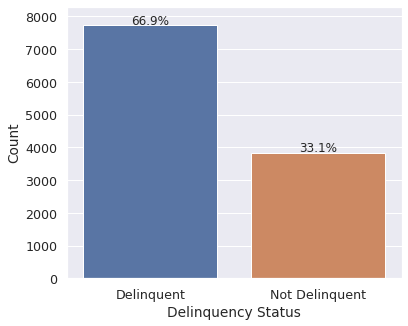

```python
plt.figure(figsize = (6, 5));
cntplt = sns.countplot(data = df, x = df['isDelinquent'], order = [1, 0]);
countplot_labeling(cntplt, df);
plt.xlabel('Delinquency Status');
cntplt.set_xticklabels(['Delinquent', 'Not Delinquent'])
plt.ylabel('Count');
plt.ylim(0, 8300);
```

**`Loan Term`**

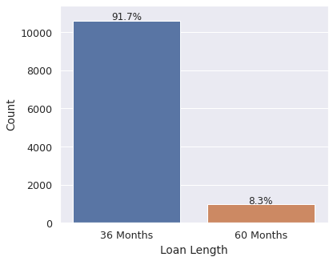

```python
plt.figure(figsize = (6, 5));
cntplt = sns.countplot(data = df, x = df['term']);
countplot_labeling(cntplt, df);
plt.xlabel('Loan Length');
cntplt.set_xticklabels(['36 Months', '60 Months']);
plt.ylabel('Count');
plt.ylim(0, 11400);
```

**`Sex`**

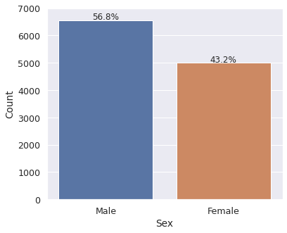

```python
plt.figure(figsize = (6, 5));
cntplt = sns.countplot(data = df, x = df['gender'], order = ['Male', 'Female']);
countplot_labeling(cntplt, df);
plt.xlabel('Sex');
plt.ylabel('Count');
plt.ylim(0, 7000);
```

**`Purpose of Loan`**

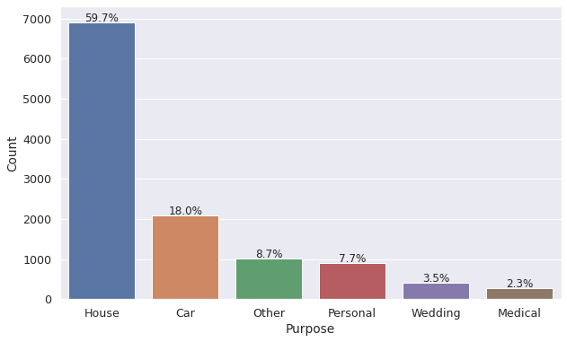

```python
plt.figure(figsize = (10, 6));
cntplt = sns.countplot(data = df, x = df['purpose'],
                       order = df.purpose.value_counts(ascending = False).index.tolist());
countplot_labeling(cntplt, df);
plt.xlabel('Purpose');
plt.ylabel('Count');
plt.ylim(0, 7300);
```

**`Home Ownership Status`**

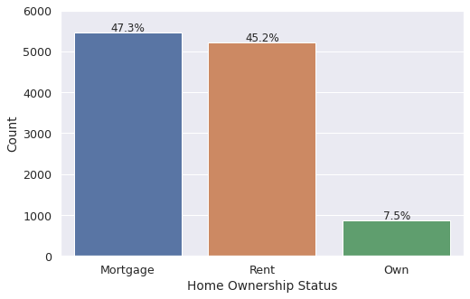

```python
plt.figure(figsize = (8, 5));
cntplt = sns.countplot(data = df, x = df['home_ownership'],
                       order = df.home_ownership.value_counts(ascending = False).index.tolist());
countplot_labeling(cntplt, df);
plt.xlabel('Home Ownership Status');
plt.ylabel('Count');
plt.ylim(0, 6000);
```

**`Age Range`**

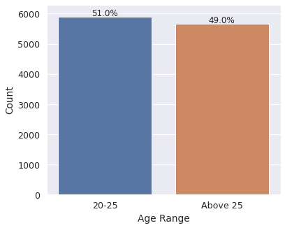

```python
plt.figure(figsize = (6, 5));
cntplt = sns.countplot(data = df, x = df['age'],
                       order = df.age.value_counts(ascending = False).index.tolist());
countplot_labeling(cntplt, df);
cntplt.set_xticklabels(['20-25', 'Above 25'])
plt.xlabel('Age Range');
plt.ylabel('Count');
plt.ylim(0, 6300);
```

**`Range of FICO Score`**

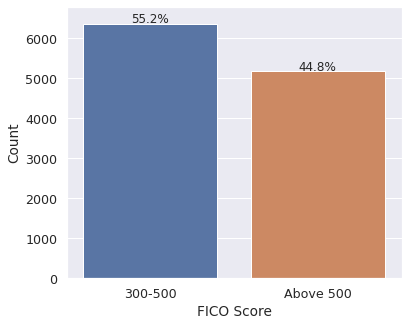

```python
plt.figure(figsize = (6, 5));
cntplt = sns.countplot(data = df, x = df['FICO'],
                       order = df.FICO.value_counts(ascending = False).index.tolist());
countplot_labeling(cntplt, df);
cntplt.set_xticklabels(['300-500', 'Above 500'])
plt.xlabel('FICO Score');
plt.ylabel('Count');
plt.ylim(0, 6800);
```

### Bivariate Analysis

**`Loan Term vs. Delinquency Status`**

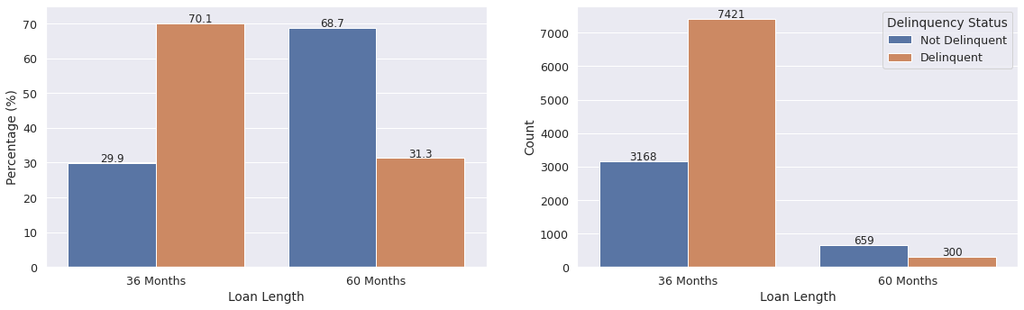

```python
# Making a crosstab of loan term and delinquency status
ctab = pd.crosstab(df['term'], df['isDelinquent'], normalize = 'index')
# Converting the crosstab into a dataframe
ctab_df = ctab.stack().reset_index()
ctab_df.rename(columns = {0: 'value'}, inplace = True)
ctab_df['isDelinquent'].replace({0: 'Not Delinquent', 1: 'Delinquent'}, inplace = True)
ctab_df.value = ctab_df.value*100

# Plotting the crosstab in percentage and count forms
plt.figure(figsize = (16, 5));
plt.subplot(121);
barplt = sns.barplot(data = ctab_df, x = 'term', hue = 'isDelinquent', y = 'value');
countplot_labeling(barplt, ctab_df, perc = False);
plt.legend().set_visible(False);
barplt.set_xticklabels(['36 Months', '60 Months']);
plt.xlabel('Loan Length');
plt.ylabel('Percentage (%)');
plt.ylim(0, 75);

plt.subplot(122);
cntplt = sns.countplot(data = df, x = 'term', hue = 'isDelinquent');
countplot_labeling(cntplt, df, perc = False);
plt.legend(title = 'Delinquency Status', labels = ['Not Delinquent', 'Delinquent']);
cntplt.set_xticklabels(['36 Months', '60 Months']);
plt.xlabel('Loan Length');
plt.ylabel('Count');
plt.ylim(0, 7800);
plt.tight_layout(w_pad = 3);
```

**`Sex vs. Delinquency Status`**

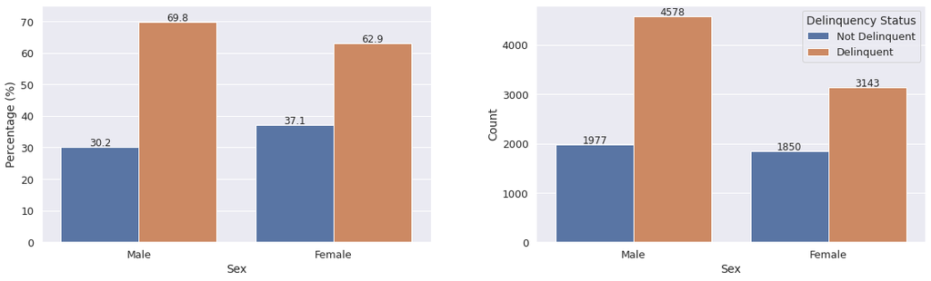

```python
# Making a crosstab of sex and delinquency status
ctab = pd.crosstab(df['gender'], df['isDelinquent'], normalize = 'index')
# Converting the crosstab into a dataframe
ctab_df = ctab.stack().reset_index()
ctab_df.rename(columns = {0: 'value'}, inplace = True)
ctab_df['isDelinquent'].replace({0: 'Not Delinquent', 1: 'Delinquent'}, inplace = True)
ctab_df.value = ctab_df.value*100

# Plotting the crosstab in percentage and count forms
plt.figure(figsize = (16, 5));
plt.subplot(121);
barplt = sns.barplot(data = ctab_df, x = 'gender', hue = 'isDelinquent', y = 'value',
                     order = ['Male', 'Female']);
countplot_labeling(barplt, ctab_df, perc = False);
plt.legend().set_visible(False);
plt.xlabel('Sex');
plt.ylabel('Percentage (%)');
plt.ylim(0, 75);

plt.subplot(122);
cntplt = sns.countplot(data = df, x = 'gender', hue = 'isDelinquent', order = ['Male', 'Female']);
countplot_labeling(cntplt, df, perc = False);
plt.legend(title = 'Delinquency Status', labels = ['Not Delinquent', 'Delinquent']);
plt.xlabel('Sex');
plt.ylabel('Count');
plt.ylim(0, 4800);
plt.tight_layout(w_pad = 5);
```

**`Loan Purpose vs. Delinquency Status`**

[figure not shown]

```python
# Making a crosstab of loan purpose and delinquency status
ctab = pd.crosstab(df['purpose'], df['isDelinquent'], normalize = 'index')
# Converting the crosstab into a dataframe
ctab_df = ctab.stack().reset_index()
ctab_df.rename(columns = {0: 'value'}, inplace = True)
ctab_df['isDelinquent'].replace({0: 'Not Delinquent', 1: 'Delinquent'}, inplace = True)
ctab_df.value = ctab_df.value*100

# Plotting the crosstab in percentage and count forms
plt.figure(figsize = (16, 5));
plt.subplot(121);
barplt = sns.barplot(data = ctab_df, x = 'purpose', hue = 'isDelinquent', y = 'value');
countplot_labeling(barplt, ctab_df, perc = False);
plt.legend().set_visible(False);
plt.xlabel('Loan Purpose');
plt.ylabel('Percentage (%)');
plt.ylim(0, 75);

plt.subplot(122);
cntplt = sns.countplot(data = df, x = 'purpose', hue = 'isDelinquent');
countplot_labeling(cntplt, df, perc = False);
plt.legend(title = 'Delinquency Status', labels = ['Not Delinquent', 'Delinquent']);
plt.xlabel('Loan Purpose');
plt.ylabel('Count');
plt.ylim(0, 4950);
plt.tight_layout(w_pad = 3);
```

**`Home Ownership Status vs. Delinquency Status`**

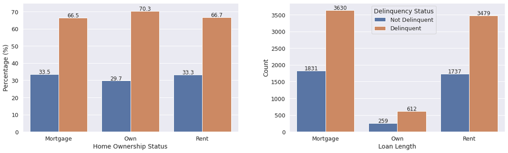

```python
# Making a crosstab of home ownership status and delinquency status
ctab = pd.crosstab(df['home_ownership'], df['isDelinquent'], normalize = 'index')
# Converting the crosstab into a dataframe
ctab_df = ctab.stack().reset_index()
ctab_df.rename(columns = {0: 'value'}, inplace = True)
ctab_df['isDelinquent'].replace({0: 'Not Delinquent', 1: 'Delinquent'}, inplace = True)
ctab_df.value = ctab_df.value*100

# Plotting the crosstab in percentage and count forms
plt.figure(figsize = (16, 5));
plt.subplot(121);
barplt = sns.barplot(data = ctab_df, x = 'home_ownership', hue = 'isDelinquent', y = 'value');
countplot_labeling(barplt, ctab_df, perc = False);
plt.legend().set_visible(False);
plt.xlabel('Home Ownership Status');
plt.ylabel('Percentage (%)');
plt.ylim(0, 75);

plt.subplot(122);
cntplt = sns.countplot(data = df, x = 'home_ownership', hue = 'isDelinquent');
countplot_labeling(cntplt, df, perc = False);
plt.legend(title = 'Delinquency Status', labels = ['Not Delinquent', 'Delinquent'],
           loc = 'upper center', bbox_to_anchor = [0.53, 1]);
plt.xlabel('Loan Length');
plt.ylabel('Count');
plt.ylim(0, 3850);
plt.tight_layout(w_pad = 4);
```

**`Age vs. Delinquency Status`**

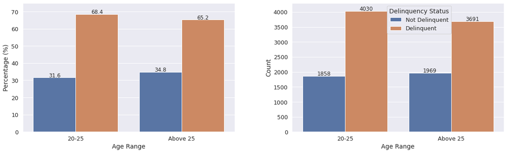

```python
# Making a crosstab of age range and delinquency status
ctab = pd.crosstab(df['age'], df['isDelinquent'], normalize = 'index')
# Converting the crosstab into a dataframe
ctab_df = ctab.stack().reset_index()
ctab_df.rename(columns = {0: 'value'}, inplace = True)
ctab_df['isDelinquent'].replace({0: 'Not Delinquent', 1: 'Delinquent'}, inplace = True)
ctab_df.value = ctab_df.value*100

# Plotting the crosstab in percentage and count forms
plt.figure(figsize = (16, 5));
plt.subplot(121);
barplt = sns.barplot(data = ctab_df, x = 'age', hue = 'isDelinquent', y = 'value');
countplot_labeling(barplt, ctab_df, perc = False);
plt.legend().set_visible(False);
barplt.set_xticklabels(['20-25', 'Above 25']);
plt.xlabel('Age Range');
plt.ylabel('Percentage (%)');
plt.ylim(0, 75);

plt.subplot(122);
cntplt = sns.countplot(data = df, x = 'age', hue = 'isDelinquent');
countplot_labeling(cntplt, df, perc = False);
plt.legend(title = 'Delinquency Status', labels = ['Not Delinquent', 'Delinquent'],
           loc = 'upper center', bbox_to_anchor = [0.6, 1]);
cntplt.set_xticklabels(['20-25', 'Above 25']);
plt.xlabel('Age Range');
plt.ylabel('Count');
plt.ylim(0, 4300);
plt.tight_layout(w_pad = 5);
```

**`FICO Score vs. Delinquency Status`**

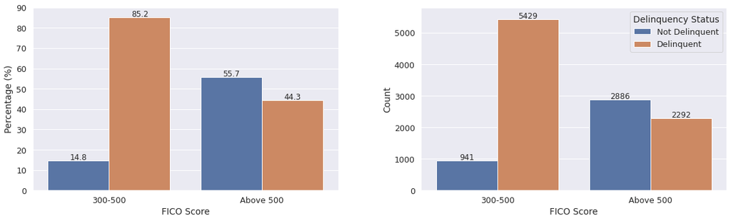

```python
# Making a crosstab of age range and delinquency status
ctab = pd.crosstab(df['FICO'], df['isDelinquent'], normalize = 'index')
# Converting the crosstab into a dataframe
ctab_df = ctab.stack().reset_index()
ctab_df.rename(columns = {0: 'value'}, inplace = True)
ctab_df['isDelinquent'].replace({0: 'Not Delinquent', 1: 'Delinquent'}, inplace = True)
ctab_df.value = ctab_df.value*100

# Plotting the crosstab in percentage and count forms
plt.figure(figsize = (16, 5));
plt.subplot(121);
barplt = sns.barplot(data = ctab_df, x = 'FICO', hue = 'isDelinquent', y = 'value');
countplot_labeling(barplt, ctab_df, perc = False);
plt.legend().set_visible(False);
barplt.set_xticklabels(['300-500', 'Above 500']);
plt.xlabel('FICO Score');
plt.ylabel('Percentage (%)');
plt.ylim(0, 90);

plt.subplot(122);
cntplt = sns.countplot(data = df, x = 'FICO', hue = 'isDelinquent');
countplot_labeling(cntplt, df, perc = False);
plt.legend(title = 'Delinquency Status', labels = ['Not Delinquent', 'Delinquent']);
cntplt.set_xticklabels(['300-500', 'Above 500']);
plt.xlabel('FICO Score');
plt.ylabel('Count');
plt.ylim(0, 5800);
plt.tight_layout(w_pad = 5);
```

**`Sex vs. FICO Score`**

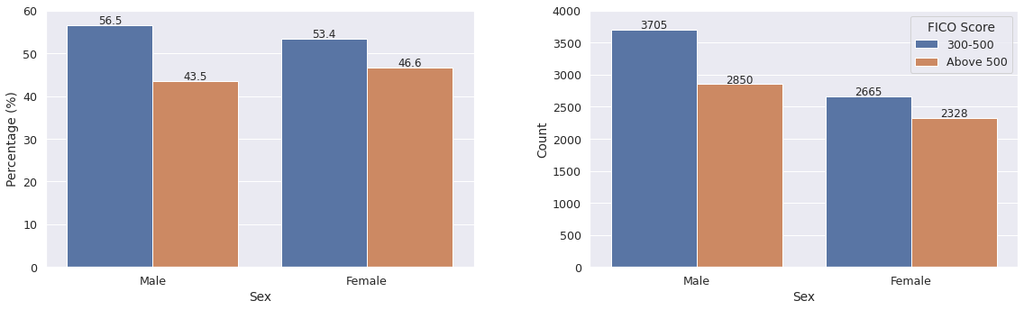

```python
# Making a crosstab of age range and FICO score range
ctab = pd.crosstab(df['gender'], df['FICO'], normalize = 'index')
# Converting the crosstab into a dataframe
ctab_df = ctab.stack().reset_index()
ctab_df.rename(columns = {0: 'value'}, inplace = True)
ctab_df['FICO'].replace({'>500': 'Above 500'}, inplace = True)
ctab_df.value = ctab_df.value*100

# Plotting the crosstab in percentage and count forms
plt.figure(figsize = (16, 5));
plt.subplot(121);
barplt = sns.barplot(data = ctab_df, x = 'gender', hue = 'FICO', y = 'value',
                     order = ['Male', 'Female']);
countplot_labeling(barplt, ctab_df, perc = False);
plt.legend().set_visible(False);
plt.xlabel('Sex');
plt.ylabel('Percentage (%)');
plt.ylim(0, 60);

plt.subplot(122);
cntplt = sns.countplot(data = df, x = 'gender', hue = 'FICO', order = ['Male', 'Female']);
countplot_labeling(cntplt, df, perc = False);
plt.legend(title = 'FICO Score', labels = ['300-500', 'Above 500']);
plt.xlabel('Sex');
plt.ylabel('Count');
plt.ylim(0, 4000);
plt.tight_layout(w_pad = 5);
```

**`Age vs. FICO Score`**

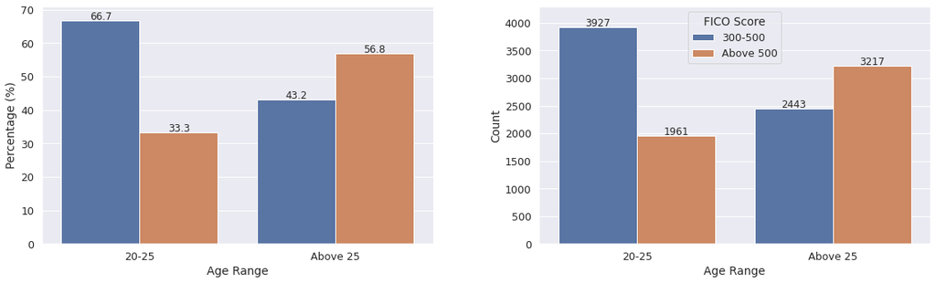

```python
# Making a crosstab of age range and FICO score range
ctab = pd.crosstab(df['age'], df['FICO'], normalize = 'index')
# Converting the crosstab into a dataframe
ctab_df = ctab.stack().reset_index()
ctab_df.rename(columns = {0: 'value'}, inplace = True)
ctab_df['FICO'].replace({'>500': 'Above 500'}, inplace = True)
ctab_df.value = ctab_df.value*100

# Plotting the crosstab in percentage and count forms
plt.figure(figsize = (16, 5));
plt.subplot(121);
barplt = sns.barplot(data = ctab_df, x = 'age', hue = 'FICO', y = 'value');
countplot_labeling(barplt, ctab_df, perc = False);
plt.legend().set_visible(False);
barplt.set_xticklabels(['20-25', 'Above 25']);
plt.xlabel('Age Range');
plt.ylabel('Percentage (%)');
plt.ylim(0, 71);

plt.subplot(122);
cntplt = sns.countplot(data = df, x = 'age', hue = 'FICO');
countplot_labeling(cntplt, df, perc = False);
plt.legend(title = 'FICO Score', labels = ['300-500', 'Above 500'],
           loc = 'upper center', bbox_to_anchor = [0.5, 1]);
cntplt.set_xticklabels(['20-25', 'Above 25']);
plt.xlabel('Age Range');
plt.ylabel('Count');
plt.ylim(0, 4300);
plt.tight_layout(w_pad = 5);
```

**`Home Ownership Status vs. FICO Score`**

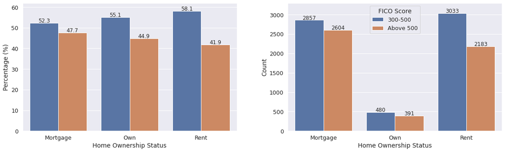

```python
# Making a crosstab of home ownership status range and FICO score range
ctab = pd.crosstab(df['home_ownership'], df['FICO'], normalize = 'index')
# Converting the crosstab into a dataframe
ctab_df = ctab.stack().reset_index()
ctab_df.rename(columns = {0: 'value'}, inplace = True)
ctab_df['FICO'].replace({'>500': 'Above 500'}, inplace = True)
ctab_df.value = ctab_df.value*100

# Plotting the crosstab in percentage and count forms
plt.figure(figsize = (16, 5));
plt.subplot(121);
barplt = sns.barplot(data = ctab_df, x = 'home_ownership', hue = 'FICO', y = 'value');
countplot_labeling(barplt, ctab_df, perc = False);
plt.legend().set_visible(False);
plt.xlabel('Home Ownership Status');
plt.ylabel('Percentage (%)');
plt.ylim(0, 62);

plt.subplot(122);
cntplt = sns.countplot(data = df, x = 'home_ownership', hue = 'FICO');
countplot_labeling(cntplt, df, perc = False);
plt.legend(title = 'FICO Score', labels = ['300-500', 'Above 500'],
           loc = 'upper center', bbox_to_anchor = [0.5, 1]);
plt.xlabel('Home Ownership Status');
plt.ylabel('Count');
plt.ylim(0, 3300);
plt.tight_layout(w_pad = 4);
```

### Hypothesis Testing

Here we ensure whether there are statically significant associations between a few pairs of variables.

$H_0$: The association between the two variable is weak.

$H_a$: The association between the two variable is statistically significant.

**`FICO Score & Delinquency Status`**

```python
# Beuilding the dataset required for statistical test
test_data = pd.crosstab(df['FICO'], df['isDelinquent'])

# Running the hypothesis testing
chi2, p_val, dof, expected = stats.chi2_contingency(test_data)

# Reporting the result of the test
print('p-value =', p_val)
if(p_val >= 0.05):
  print('The association between FICO score and delinquency status is too weak.')
else:
  print('There is a statistically significant association between FICO score and delinquency status.')
```

[output not shown]

**`Sex & FICO Score`**

```python
# Beuilding the dataset required for statistical test
test_data = pd.crosstab(df['gender'], df['FICO'])

# Running the hypothesis testing
chi2, p_val, dof, expected = stats.chi2_contingency(test_data)

# Reporting the result of the test
print('p-value =', np.round(p_val, 6))
if(p_val >= 0.05):
  print('The association between sex and FICO score is too weak.')
else:
  print('There is a statistically significant association between sex and FICO score.')
```

```
p-value = 0.000809
There is a statistically significant association between sex and FICO score.
```

**`Age & FICO Score`**

```python
# Beuilding the dataset required for statistical test
test_data = pd.crosstab(df['age'], df['FICO'])

# Running the hypothesis testing
chi2, p_val, dof, expected = stats.chi2_contingency(test_data)

# Reporting the result of the test
print('p-value =', np.round(p_val, 20))
if(p_val >= 0.05):
  print('The association between age and FICO score is too weak.')
else:
  print('There is a statistically significant association between age and FICO score.')
```

```
p-value = 0.0
There is a statistically significant association between age and FICO score.
```

**`Home Ownership & FICO Score`**

```python
# Beuilding the dataset required for statistical test
test_data = pd.crosstab(df['home_ownership'], df['FICO'])

# Running the hypothesis testing
chi2, p_val, dof, expected = stats.chi2_contingency(test_data)

# Reporting the result of the test
print('p-value =', np.round(p_val, 11))
if(p_val >= 0.05):
  print('The association between home ownership status and FICO score is too weak.')
else:
  print('There is a statistically significant association between home ownership status and FICO score.')
```

```
p-value = 1.083e-08
There is a statistically significant association between home ownership status and FICO score.
```

## Model Building - Decision Tree Model

```python
# Auxiliary function for displaying the model's performance

def model_performance(model, X_train, y_train, X_test, y_test):
  '''This function reports the import metrics of accuracy for
  a developed decision-tree-based model.'''

  y_recon = model.predict(X_train)
  y_pred = model.predict(X_test)

  metrics_df = pd.DataFrame(index = ['Train', 'Test'],
                            columns = ['Accuracy', 'Recall', 'Precision', 'Specificity', 'F1'])

  metrics_df.iloc[0, :] = [accuracy_score(y_train, y_recon), recall_score(y_train, y_recon),
                           precision_score(y_train, y_recon), recall_score(y_train, y_recon, pos_label = 0),
                           f1_score(y_train, y_recon)]

  metrics_df.iloc[1, :] = [accuracy_score(y_test, y_pred), recall_score(y_test, y_pred),
                           precision_score(y_test, y_pred), recall_score(y_test, y_pred, pos_label = 0),
                           f1_score(y_test, y_pred)]

  return metrics_df
```

```python
def make_confusion_matrix(y_true, y_pred):

  cm = confusion_matrix(y_true, y_pred)
  cm_df = pd.DataFrame(cm, index = ['Actual - False', 'Actual - True'],
                       columns = ['Forecast - False', 'Forecast - True'])

  num_perc = []
  for i in range(len(cm.flatten())):
    num_perc.append(str(cm.flatten()[i]) + '\n(' + str(np.round(cm.flatten()[i]/cm.flatten().sum()*100, 2)) + '%)')
  num_perc = np.array(num_perc)
  num_perc = num_perc.reshape(2, 2)

  plt.figure(figsize = (6, 5));
  sns.heatmap(cm_df, fmt = '', annot = num_perc, cbar = False, cmap = 'seismic',
              vmin = -1.05*np.max(cm.flatten()), vmax = 1.05*np.max(cm.flatten()));
  plt.xlabel('Prediction')
  plt.ylabel('Original Data')
```

### Full Tree Model

```python
# Separating target and predictors
df['isDelinquent'] = df['isDelinquent'].astype(float)
y = df['isDelinquent']
X = df.drop(columns = 'isDelinquent', axis = 1)
```

```python
# Converting categories into dummy variables
X = pd.get_dummies(X, columns = X.select_dtypes(include = ['category']).columns.tolist(), drop_first = True)
X.head()
```

|  | term_60 months | gender_Male | purpose_House | purpose_Medical | purpose_Other | purpose_Personal | purpose_Wedding | home_ownership_Own | home_ownership_Rent | age_>25 | FICO_>500 |
| --- | --- | --- | --- | --- | --- | --- | --- | --- | --- | --- | --- |
| 0 | 0 | 0 | 1 | 0 | 0 | 0 | 0 | 0 | 0 | 1 | 0 |
| 1 | 0 | 0 | 1 | 0 | 0 | 0 | 0 | 0 | 1 | 0 | 1 |
| 2 | 0 | 0 | 1 | 0 | 0 | 0 | 0 | 0 | 1 | 1 | 0 |
| 3 | 0 | 0 | 0 | 0 | 0 | 0 | 0 | 0 | 0 | 1 | 0 |
| 4 | 0 | 0 | 1 | 0 | 0 | 0 | 0 | 0 | 1 | 1 | 0 |

```python
# Separating dataset into training and testing sets with a 70:30 ratio
X_train, X_test, y_train, y_test = train_test_split(X, y, test_size = 0.3, random_state = 1, stratify = y)

print(X_train.head(3), end = '\n' + '--'*30 + '\n')
print(X_test.head(3))
```

```
       term_60 months  gender_Male  purpose_House  purpose_Medical  \
2763                0            0              1                0
6008                0            1              1                0
10373               0            0              0                0

       purpose_Other  purpose_Personal  purpose_Wedding  home_ownership_Own  \
2763               0                 0                0                   0
6008               0                 0                0                   0
10373              0                 0                1                   0

       home_ownership_Rent  age_>25  FICO_>500
2763                     0        1          0
6008                     1        0          0
10373                    0        1          0
------------------------------------------------------------
       term_60 months  gender_Male  purpose_House  purpose_Medical  \
10506               0            0              0                1
3027                0            0              0                0
6294                1            1              1                0

       purpose_Other  purpose_Personal  purpose_Wedding  home_ownership_Own  \
10506              0                 0                0                   1
3027               0                 1                0                   0
6294               0                 0                0                   0

       home_ownership_Rent  age_>25  FICO_>500
10506                    0        1          1
3027                     1        1          1
6294                     0        1          0
```

```python
# Checking the proportional splitting of delinquency status between training & testing sets
print('The ratio of delinquents in training set:', np.round(y_train.sum()/y_train.shape[0], 3))
print('The ratio of delinquents in testing set:', np.round(y_test.sum()/y_test.shape[0], 3))
```

```
The ratio of delinquents in training set: 0.669
The ratio of delinquents in testing set: 0.669
```

```python
# Building the full tree model
tree_full = DecisionTreeClassifier(criterion = 'gini', random_state = 1)
tree_full = tree_full.fit(X_train, y_train)
```

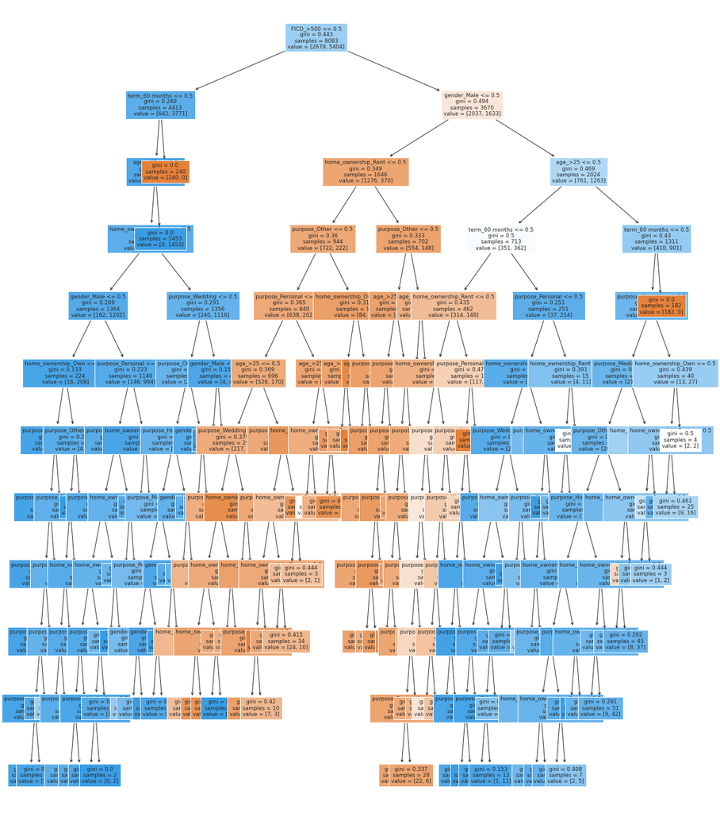

```python
# Illustraining the resulting tree
predictors = X.columns.tolist()
plt.figure(figsize = (20, 25))
tree.plot_tree(tree_full, feature_names = predictors, filled = True, fontsize = 9, node_ids = False, class_names = None)
plt.show()
```

```python
# Printing the equations of the tree
predictors = X.columns.tolist()
print(tree.export_text(tree_full, feature_names = predictors, show_weights = True, max_depth = 11))
```

```
|--- FICO_>500 <= 0.50
|   |--- term_60 months <= 0.50
|   |   |--- age_>25 <= 0.50
|   |   |   |--- home_ownership_Rent <= 0.50
|   |   |   |   |--- gender_Male <= 0.50
|   |   |   |   |   |--- home_ownership_Own <= 0.50
|   |   |   |   |   |   |--- purpose_Medical <= 0.50
|   |   |   |   |   |   |   |--- purpose_Wedding <= 0.50
|   |   |   |   |   |   |   |   |--- purpose_Personal <= 0.50
|   |   |   |   |   |   |   |   |   |--- purpose_Other <= 0.50
|   |   |   |   |   |   |   |   |   |   |--- purpose_House <= 0.50
|   |   |   |   |   |   |   |   |   |   |   |--- weights: [2.00, 28.00] class: 1.0
|   |   |   |   |   |   |   |   |   |   |--- purpose_House >  0.50
|   |   |   |   |   |   |   |   |   |   |   |--- weights: [7.00, 104.00] class: 1.0
|   |   |   |   |   |   |   |   |   |--- purpose_Other >  0.50
|   |   |   |   |   |   |   |   |   |   |--- weights: [1.00, 9.00] class: 1.0
|   |   |   |   |   |   |   |   |--- purpose_Personal >  0.50
|   |   |   |   |   |   |   |   |   |--- weights: [1.00, 30.00] class: 1.0
|   |   |   |   |   |   |   |--- purpose_Wedding >  0.50
|   |   |   |   |   |   |   |   |--- weights: [0.00, 9.00] class: 1.0
|   |   |   |   |   |   |--- purpose_Medical >  0.50
|   |   |   |   |   |   |   |--- weights: [1.00, 3.00] class: 1.0
|   |   |   |   |   |--- home_ownership_Own >  0.50
|   |   |   |   |   |   |--- purpose_Other <= 0.50
|   |   |   |   |   |   |   |--- purpose_Personal <= 0.50
|   |   |   |   |   |   |   |   |--- purpose_Medical <= 0.50
|   |   |   |   |   |   |   |   |   |--- purpose_House <= 0.50
|   |   |   |   |   |   |   |   |   |   |--- weights: [1.00, 2.00] class: 1.0
|   |   |   |   |   |   |   |   |   |--- purpose_House >  0.50
|   |   |   |   |   |   |   |   |   |   |--- weights: [3.00, 16.00] class: 1.0
|   |   |   |   |   |   |   |   |--- purpose_Medical >  0.50
|   |   |   |   |   |   |   |   |   |--- weights: [0.00, 1.00] class: 1.0
|   |   |   |   |   |   |   |--- purpose_Personal >  0.50
|   |   |   |   |   |   |   |   |--- weights: [0.00, 2.00] class: 1.0
|   |   |   |   |   |   |--- purpose_Other >  0.50
|   |   |   |   |   |   |   |--- weights: [0.00, 4.00] class: 1.0
|   |   |   |   |--- gender_Male >  0.50
|   |   |   |   |   |--- purpose_Personal <= 0.50
|   |   |   |   |   |   |--- purpose_Other <= 0.50
|   |   |   |   |   |   |   |--- purpose_Wedding <= 0.50
```

[output cut: 318 more lines]

```
|   |   |   |   |   |   |   |   |--- weights: [4.00, 10.00] class: 1.0
|   |   |   |   |   |   |   |--- home_ownership_Own >  0.50
|   |   |   |   |   |   |   |   |--- weights: [1.00, 2.00] class: 1.0
|   |   |   |   |   |   |--- home_ownership_Rent >  0.50
|   |   |   |   |   |   |   |--- weights: [5.00, 7.00] class: 1.0
|   |   |   |   |--- purpose_Wedding >  0.50
|   |   |   |   |   |--- home_ownership_Own <= 0.50
|   |   |   |   |   |   |--- home_ownership_Rent <= 0.50
|   |   |   |   |   |   |   |--- weights: [2.00, 9.00] class: 1.0
|   |   |   |   |   |   |--- home_ownership_Rent >  0.50
|   |   |   |   |   |   |   |--- weights: [9.00, 16.00] class: 1.0
|   |   |   |   |   |--- home_ownership_Own >  0.50
|   |   |   |   |   |   |--- weights: [2.00, 2.00] class: 0.0
|   |   |   |--- term_60 months >  0.50
|   |   |   |   |--- weights: [182.00, 0.00] class: 0.0
```

```python
# Evaluating the performance of the model
full_tree_performance = model_performance(tree_full, X_train, y_train, X_test, y_test)
full_tree_performance
```

|  | Accuracy | Recall | Precision | Specificity | F1 |
| --- | --- | --- | --- | --- | --- |
| Train | 0.85 | 0.90 | 0.88 | 0.75 | 0.89 |
| Test | 0.84 | 0.90 | 0.87 | 0.72 | 0.89 |

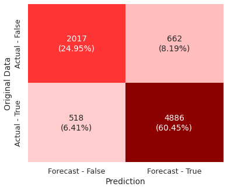

```python
# Making a confusion matrix for training set
y_recon = tree_full.predict(X_train)
make_confusion_matrix(y_train, y_recon)
```

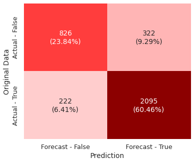

```python
# Making a confusion matrix for testing set
y_pred = tree_full.predict(X_test)
make_confusion_matrix(y_test, y_pred)
```

```python
# Sorting the predictors based on their importance in the tree-based model
features_significance = pd.Series(tree_full.feature_importances_, index = X.columns.tolist())
features_significance = features_significance.sort_values(ascending = False)
features_significance
```

```
FICO_>500             0.39
term_60 months        0.38
gender_Male           0.17
age_>25               0.04
home_ownership_Rent   0.01
home_ownership_Own    0.01
purpose_Wedding       0.00
purpose_Personal      0.00
purpose_House         0.00
purpose_Medical       0.00
purpose_Other         0.00
dtype: float64
```

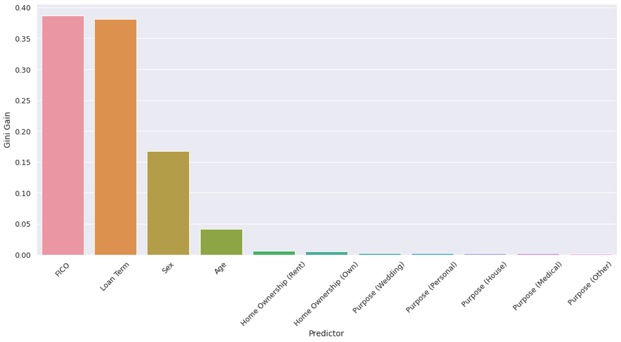

```python
# Plotting the significance of each predictor according to the tree-based model
plt.figure(figsize = (18, 8));
barplt = sns.barplot(x = features_significance.index, y = features_significance.values);
barplt.set_xticklabels(['FICO', 'Loan Term', 'Sex', 'Age', 'Home Ownership (Rent)', 'Home Ownership (Own)',
                        'Purpose (Wedding)', 'Purpose (Personal)', 'Purpose (House)', 'Purpose (Medical)',
                       'Purpose (Other)'])
plt.xlabel('Predictor');
plt.ylabel('Gini Gain');
plt.xticks(rotation = 45);
```